# CRISPRi library additional tests

## Description

The purpose of this R markdown notebook is to provide a trackable, reproducible, and comprehensive documentation of data processing steps for experiments carried out using a CRISPRi sgRNA library in the cyanobacterium *Synechocystis* sp. PCC6803.

This is an additional part of the pipeline where other tracks are explored by blending the fitness results of the CRISPRi library with protein abundance or protein variability. The additional data set used here is a proteomics study from [Jahn et al., Cell Reports, 2018](https://linkinghub.elsevier.com/retrieve/pii/S2211124718314852). The idea is that gene/protein essentiality could correlate with variability in protein abundance. One scenario would be that ‘core proteins’ are both essential and less variable in abundance as they are required under all possible conditions. The ‘core proteome’ (around 400 proteins in *E. coli*) was reported to be mostly allosterically regulated instead of transcriptionally.

```r
# LOAD PACKAGES

library(lattice)
library(latticeExtra)
library(grid)
library(tidyverse)
library(Rtools)
library(factoextra)
library(clusterProfiler)
library(limma)
```

## Correlation between gene fitness and gene expression variability

Preprocessed data in the form of reads per gene was summarized and annotated in pipeline 1. It includes mean read fraction, log2 FC and p-value calculated using DESeq2. Genome annotation was added based on uniprot and cyanobase annotation of the reference genome for *Synechocystis* sp. PCC6803.

#### Loading and merging proteomics data

```r
# load CRISPRi library data
load(file = "../processed_data/CRISPRi_library_df_cluster.Rdata")

# exclude ncRNAs from analysis
df_all <- df
df <- df %>% filter(!grepl("^Entry", sgRNA))
```

```r
# load MS data from Cell Reports paper and combine with library
df_ms <- read_csv("../../../../../Experiments/20171204_MS_CO2/CO2_light/analysis/diffacto_weightedsum/df_long_massfrac.csv") %>%

  # we can try both light and CO2-related regulation (one ANOVA test per limitation and protein)
  # -------------------------
  # this block is for LIGHT
  # -------------------------
  filter(sample == "light", light %in% c(300, 100)) %>%

  # change sample annotation from [100, 300] to [L100, L300]
  mutate(condition = recode(light, `300` = "L300", `100` = "L100")) %>%

  # rename a column
  rename(locus = protein) %>%

  # select only the interesting columns
  select(locus, condition, mean.mass.fraction.norm, ANOVA, ANOVA.adj) %>%

  # -------------------------
  # this block is for CO2
  # -------------------------
  # filter(sample == "CO2", concentration == 1) %>%
  #
  # # rename a column
  # rename(locus = protein) %>%
  #
  # # select only the interesting columns
  # select(locus, mean.mass.fraction.norm, ANOVA, ANOVA.adj) %>%
  # -------------------------

  # merge with df
  left_join(df, .) %>%

  # filter for L100 and L300 only
  filter(condition %in% c("L100", "L300"))


# test if mass fraction sums up to _around 1_ (also depends on intersection
# between proteomics and CRISPRi library gene sets)
df_ms %>% group_by(condition, timepoint, induction, sgRNA_index) %>%
  summarise(sum(mean.mass.fraction.norm, na.rm = TRUE)) %>% head
```

| condition | timepoint | induction | sgRNA_index | sum(mean.mass.fraction.norm, na.rm = TRUE) |
| --- | --- | --- | --- | --- |
| L100 | 0 | i | 1 | 0.9760172 |
| L100 | 0 | i | 2 | 0.9760172 |
| L100 | 0 | u | 1 | 0.9760172 |
| L100 | 0 | u | 2 | 0.9760172 |
| L100 | 1 | i | 1 | 0.9760172 |
| L100 | 1 | i | 2 | 0.9760172 |

#### Correlation between change over light conditions and essentiality

Different metrics could be used to determine the extent of a protein changing abundance over light conditions. The MS dataset contains an ANOVA p-value that is lower (more significant) the more a protein changes abudnance over light intensity/ growth rate (5 light intensities were originally tested: L60, L100, L200, L300 and L1000). The p-value obtained from ANOVA is the same for all conditions. It is therefore not neccessary to include all possible light conditions. If all sgRNAs are mapped to their corresponding proteins (2 sgRNAs per protein), no correlation is visible. Also not, if optionally only the more depleted of the two sgRNAs per protein are selected.

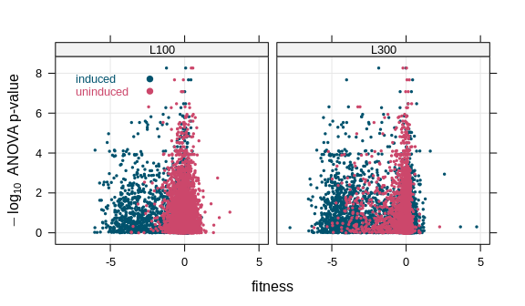

```r
# filter dataset for 1 time point only (fitness score is identical
# for all time points of 1 condition)
df_ms %>% filter(timepoint == 0) %>%

  xyplot(-log10(ANOVA.adj) ~ fitness_score | factor(condition, unique(condition)), .,
  as.table = TRUE, groups = induction,
  between = list(x = 0.5, y = 0.5),
  par.settings = custom.lattice, pch = 19, cex = 0.3,
  scales = list(alternating = FALSE),
  #xlim = c(-9, 4), ylim = c(-9, 4),
  xlab = "fitness", ylab = bquote(-log[10] ~ "ANOVA p-value"),
  panel = function(x, y, ...) {
    panel.grid(h = -1, v = -1, col = grey(0.9))
    panel.xyplot(x, y, ... )
    panel.key(c("induced", "uninduced"), pch = 19, corner = c(0.1, 0.9))
  }
)
```

However it is possible to refine the approach by selecting subsets of sgRNAs or proteins. In the following step, proteins are binned by ANOVA log10 -p-value, and fitness score distribution evaluated as box and whisker plot. Here, a trend can be seen in the form of more significantly regulated genes (higher -log10 p-value) having reduced median fitness.

```
x
   (0,0.001] (0.001,0.01]  (0.01,0.05]   (0.05,0.1]      (0.1,1]
         208          280          440          284         2702
x
   (0,0.001] (0.001,0.01]  (0.01,0.05]   (0.05,0.1]      (0.1,1]
         208          280          440          284         2702
x
   (0,0.001] (0.001,0.01]  (0.01,0.05]   (0.05,0.1]      (0.1,1]
         208          280          440          284         2702
x
   (0,0.001] (0.001,0.01]  (0.01,0.05]   (0.05,0.1]      (0.1,1]
         208          280          440          284         2702
```

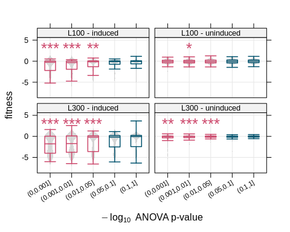

```r
# customize plotting colors a bit
custom.lattice <- custom.lattice()
custom.lattice$box.rectangle$col = rep(c("#CC476B", "#00526D"), c(3,2))
custom.lattice$box.umbrella$col = rep(c("#CC476B", "#00526D"), c(3,2))
custom.lattice$box.rectangle$lwd = 1.5
custom.lattice$box.umbrella$lwd = 1.5


# filter dataset for 1 time point only (fitness score is identical
# for all time points of 1 condition)
plot_fitness_ANOVA_bw <- df_ms %>% filter(timepoint == 0) %>%

  # bin into groups by -log10 p-value
  mutate(ANOVA_bin = cut(ANOVA.adj, breaks = c(1,0.1,0.05,0.01,0.001,0))) %>%

  xyplot(fitness_score ~ factor(ANOVA_bin) | factor(condition) %>%
      paste0(" - ", recode(induction, i = "induced", u = "uninduced")), .,
    as.table = TRUE, between = list(x = 0.5, y = 0.5),
    par.settings = custom.lattice, lwd = 1.5,
    scales = list(alternating = FALSE, x = list(rot = 30, cex = 0.7)),
    xlab = bquote(-log[10] ~ "ANOVA p-value"), ylab = "fitness",
    panel = function(x, y, ...) {
      print(table(x))
      panel.grid(h = -1, v = -1, col = grey(0.9))
      panel.violin(x, y, horizontal = FALSE, border = NA, col = grey(0.7, 0.5))
      panel.bwplot(x, y, horizontal = FALSE, pch = "|", do.out = FALSE, ... )
      panel.pvalue(x, y, fixed_pos = 8, std = 5,
        col = rep(c("#CC476B", "#00526D"), c(3,2))
      )
    }
  )

print(plot_fitness_ANOVA_bw)
```

As a follow-up, the most regulated proteins were selected and the fitness of the corresponding sgRNAs was plotted as barchart (groups in red from above, $p_{value} \leq 0.05$).

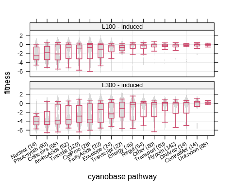

```r
# customize plotting colors a bit
custom.lattice$box.rectangle$col = "#CC476B"#"#00526D"
custom.lattice$box.umbrella$col = "#CC476B"#"#00526D"

# filter dataset for 1 time point only (fitness score is identical
# for all time points of 1 condition)
plot_fitness_ANOVA_pw <- df_ms %>%

  # filter also for most regulated genes = p-value <= 0.01
  filter(timepoint == 0, induction == "i", ANOVA.adj <= 0.05) %>%

  # arrange genes by mean fitness over pathway
  group_by(Process.abbr) %>%
  mutate(
    mean_fitness = mean(fitness_score, na.rm = TRUE),
    n_sgRNAs = length(unique(sgRNA))) %>%
  arrange(mean_fitness) %>%

  # plot fitness per pathway
  xyplot(fitness_score ~ paste0(Process.abbr, " (", n_sgRNAs, ")") %>% factor(., unique(.)) |
      paste0(condition, " - induced"), .,
    as.table = TRUE, between = list(x = 0.5, y = 0.5),
    par.settings = custom.lattice, lwd = 1.5, layout = c(1,2),
    scales = list(alternating = FALSE, x = list(rot = 30, cex = 0.7)),
    xlab = "cyanobase pathway", ylab = "fitness",
    panel = function(x, y, ...) {
      panel.grid(h = -1, v = -1, col = grey(0.9))
      panel.violin(x, y, horizontal = FALSE, border = NA, col = grey(0.7, 0.5),... )
      panel.bwplot(x, y, horizontal = FALSE, pch = "|", do.out = FALSE, ... )
    }
  )

print(plot_fitness_ANOVA_pw)
```

**Supplementary Figure. Highly regulated proteins have lower average fitness.** **a** Fitness score of sgRNAs broken down by protein variability. Protein variability was estimated using a proteomics study with measurement of protein abundance over several light conditions (Jahn et al., Cell Reports, 2018). Here, the adjusted p-value from ANOVA over all light conditions was used as a metric for variability. For this comparison, every sgRNA was mapped to its corresponding protein. Red, proteins with $p_{value} \leq 0.05$). Blue, proteins with $p_{value} > 0.05$). **b** Fitness score of sgRNAs associated with most significantly changing proteins ($p_{value} \leq 0.05$, red in (A), broken down by cyanobase pathways. In brackets, number of unique sgRNAs per pathway.

## Determine mutant growth rate from depletion over time

The main dataset contains measurements of thousands of sgRNA mutants over time. The proportion of these mutant sub-populations of the total population changes over time depending on their individual growth rate. If a mutant grows faster than the population average, it will outcompete the other mutants in terms of growth and enrich in the population. Likewise, mutants with a growth defect be diluted over time eventually get depleted from the population. Theoretically, this problem is similar to the mathematical concept of half-life as it is known from nuclear decay. At a certain rate (half-life), an unstable isotope will break apart into a more stable one releasing radiation.

#### Mathematical concept

All parameters to determine the growth rate of each individual mutant are known. The main parameters are the average growth rate ($\mu$, equals dilution rate ($D$) of the population, and the relative fraction of each mutant ($FC$) of the total population at the initial and later time points ($t_0, t_i$). If a mutant will not grow at all, it is depleted from the library at the rate of population growth ($D_{total}$). If it grows at a slower rate $D_{mutant}$, it is depleted from the library at rate $D_{diff}$.

$$D_{diff} = D_{total} - D_{mutant}$$

The depletion of a mutant from the library can be modeled for arbitrary time points, where the mutant fraction $F_t$ at time point $t$ becomes

$$F(t) = F(_{t=0}) \times (1-({D_{total}-D_{mutant}}))^{t}$$
For example, population fraction $F$ after 10 h growth with a population growth rate of $D_{total} = 0.1$, a mutant growth rate of $D_{mutant} = 0.05$, and inital population fraction of $F(t=0) = 0.1$ is $F(10 h) = 0.1 \times (1-(0.1-0.05))^{10} = 0.059$. This is effectively a growth model that can be fitted to each sgRNA using the known parameters $F(t=0)$, $D_{total}$, and $F(t)$, and solving for $D_{mutant}$. To make things easier, it is possibe to use the fold change (FC) as normalized measure of read fraction. Then initial population fraction becomes 1 ($F(t=0) = 1$) and can be removed from the equation. To fit this model to sgRNA depletion, R’s standard non-linear fitting system `nls()` can be used.

#### Implementation

We prepare a reduced data frame with time in days being converted to time in hours (to match growth rate per hour).

```r
df_mu <- df %>% ungroup %>%
  mutate(timepoint = timepoint * 24) %>%
  select(condition, timepoint, induction, sgRNA, sgRNA_short, sgRNA_index, locus,
    FC, average_growth_rate, Process.abbr)

# use a wrapper function for nls() that we can apply on whole data frame
fit_mu <- function(time, pop_mu, FC) {
  # wrap function in a tryCatch statement to handle max iteration errors
  model <- tryCatch(error = function(e) {NULL},
    nls(
      formula = FC ~ (1 - (pop_mu - mut_mu))^time,
      data = data.frame(time = time, pop_mu = pop_mu, FC = FC),
      start = list(mut_mu = 0.01)
    )
  )
  # test for errors and return result
  if (is.null(model)) {
    return(NA)
  } else {
    summary(model)[["parameters"]][[1]]
  }
}


# add modeled depletion to data frame using fitted mutant growth rate
df_mu <- df_mu %>% group_by(condition, induction, sgRNA) %>%
  mutate(
    mutant_growth_rate = fit_mu(timepoint, average_growth_rate, FC),
    FC_fit = (1 - (average_growth_rate - mutant_growth_rate))^timepoint
  )

# preview
df_mu %>% head
```

| condition | timepoint | induction | sgRNA | sgRNA_short | sgRNA_index | locus | FC | average_growth_rate | Process.abbr | mutant_growth_rate | FC_fit |
| --- | --- | --- | --- | --- | --- | --- | --- | --- | --- | --- | --- |
| L100 | 0 | i | aat_22 | aat | 1 | sll0869 | 1.0000000 | 0.0315 | Translat | 0.03233289 | 1.000000 |
| L100 | 0 | u | aat_22 | aat | 1 | sll0869 | 1.0000000 | 0.0289 | Translat | 0.02899592 | 1.000000 |
| L100 | 24 | i | aat_22 | aat | 1 | sll0869 | 0.9778916 | 0.0315 | Translat | 0.03233289 | 1.020182 |
| L100 | 24 | u | aat_22 | aat | 1 | sll0869 | 0.8756021 | 0.0289 | Translat | 0.02899592 | 1.002305 |
| L100 | 48 | i | aat_22 | aat | 1 | sll0869 | 1.0988626 | 0.0315 | Translat | 0.03233289 | 1.040771 |
| L100 | 48 | u | aat_22 | aat | 1 | sll0869 | 1.2204668 | 0.0289 | Translat | 0.02899592 | 1.004615 |

```r
# save the data
write_csv(df_mu, "../processed_data/CRISPRi_library_df_growthrates.csv")
```

The result from the growth models is the estimated parameter, the mutant growth rate, and the predicted depletion/enrichment over time in fold change (`FC_fit`). However, a first necessary check is to see how many genes failed to get a growth model fitted. Second, the distribution of mutant growth rates can be plotted.

```r
# check how many models failed (mostly due to NA/missing values)
df_mu %>% group_by(condition, induction) %>% filter(timepoint == 0) %>%
  summarise(
    successful_models = sum(!is.na(mutant_growth_rate)),
    failed_models = sum(is.na(mutant_growth_rate))
  )
```

| condition | induction | successful_models | failed_models |
| --- | --- | --- | --- |
| L100 | i | 7064 | 8 |
| L100 | u | 7069 | 3 |
| L300 | i | 7065 | 7 |
| L300 | u | 7070 | 2 |
| Lactate | i | 1224 | 5848 |
| Lactate | u | 341 | 6731 |
| LD | i | 813 | 6259 |
| LD | u | 2 | 7070 |
| NaCl | i | 0 | 7072 |

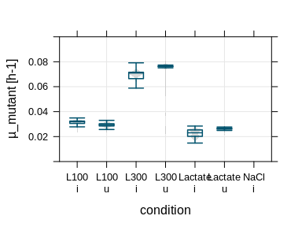

```r
# customize plotting colors a bit
custom.lattice <- custom.lattice()
custom.lattice$box.rectangle$col = "#00526D"
custom.lattice$box.umbrella$col = "#00526D"
custom.lattice$box.rectangle$lwd = 1.5
custom.lattice$box.umbrella$lwd = 1.5

# plot mutant growth rates
xyplot(mutant_growth_rate ~ paste0(condition, "\n", induction) %>% factor,
  df_mu %>% ungroup %>%
    filter(timepoint == 0, condition != "LD"), groups = induction,
  as.table = TRUE, between = list(x = 0.5, y = 0.5),
  par.settings = custom.lattice, lwd = 1.5,
  xlab = "condition", ylab = "µ_mutant [h-1]",
  ylim = c(0, 0.1),
  scales = list(alternating = FALSE),
  panel = function(x, y, ...) {
    panel.grid(h = -1, v = -1, col = grey(0.9))
    panel.violin(x, y, horizontal = FALSE, border = NA, col = grey(0.7, 0.5),... )
    panel.bwplot(x, y, horizontal = FALSE, pch = "|", do.out = FALSE, ... )
  }
)
```

#### Growth rate of sgRNA mutants for selected pathways

We can plot the *predicted* depletion/enrichment over time *versus* the *actual* depletion/enrichment. Different sets of interesting genes or pathways could be selected. For a start, a selection of genes for **photorespiration** and for **Calvin cycle** related genes can be created. The next step is to compare the fitted growth rates for individual mutants, for example between induced and non-induced conditions.

#### Faster growing sgRNA mutants

A few clones actually gained a condition-dependent fitness advantage over the population average. In the case of the turbidostat, cells are selected for maximum specific growth rate and maximizing fitness is therefore reduced to maximizing steady-state growth rate for a particular condition. In the next paragraph, not only mutants for specific pathways but also faster-growing mutants are ‘isolated’.

```r
# Photorespiration genes (extracted from Hagemann papers)
list_photores <- c(
  "sll0404", "slr0806", "sll0171", "slr0229", "slr1348",
  "sll1349", "sll1981", "slr2088", "sll1559", "slr1931"
)

# Calvin cycle genes
list_calvin <- c(
  "sll1525", "slr0012", "slr0009", "slr0394", "sll1342",
  "slr0884", "slr0943", "sll0018", "slr0952", "slr2094",
  "sll1070", "slr0194", "ssl2153", "slr0783", "sll0807",
  "slr1793", "sll0587", "sll1275", "slr0752", "slr1945",
  "slr0084", "slr1349", "slr1124", "sll0395", "slr1748"
)

# faster growing mutants
list_faster <- c(
  "sll1968", "sll1969", "slr1916", "slr1340", "ssl2982"
)
```

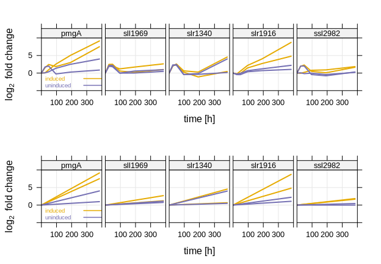

```r
# custom color vector
custom_palette <- RColorBrewer::brewer.pal(8, "Dark2")

# plot fitted model and actual depletion together for subset of sgRNAs
plot_mutant_mu <- lapply(c("FC", "FC_fit"), function(var) {
  xyplot(log2(get(var)) ~ timepoint | sgRNA_short,
    df_mu %>% ungroup %>% filter(locus %in% list_faster, condition == "L300"),
    groups = paste(induction, sgRNA_index), col = rep(custom_palette[c(6,3)], each = 2),
    as.table = TRUE, between = list(x = 0.3, y = 0.3), layout = c(5, 1),
    par.settings = custom.lattice, type = "l", lwd = 2,
    xlab = "time [h]", ylab = bquote(log[2] ~ "fold change"),
    xlim = c(0, 400), ylim = c(-5, 10),
    scales = list(alternating = FALSE),
    panel = function(x, y, ...) {
      panel.grid(h = -1, v = -1, col = grey(0.9))
      panel.xyplot(x, y, ...)
      panel.key(c("induced", "uninduced"), corner = c(0.1,0.05),
        col = custom_palette[c(6,3)], points = FALSE, lines = TRUE, cex = 0.6)
    }
  )
})

print(plot_mutant_mu[[1]], position = c(0,0.5,1,1), more = TRUE)
print(plot_mutant_mu[[2]], position = c(0,0,1,0.5))
```

Comparison of growth rate for the selected genes. Mutant growth rate is aggregated as mean and standard deviation of the two sgRNAs. Induced *versus* uninduced condition is plotted. More informative than plotting actual growth rates is plotting the % of change in growth rate compared to the population average. The table with mutant growth rate of all selected strains is saved as a *Supplementary Data* table.

```r
plot_mutant_mu_2 <- lapply(list(list_calvin, list_photores, list_faster), function(genes) {

  # adjust scale to selected gene set
  if ("slr1916" %in% genes) ylim = c(90, 130) else ylim = c(-50, 150)

  df_mu %>% ungroup %>%

  # select subset of sgRNA
  filter(locus %in% genes, condition %in% c("L100", "L300")) %>%

  # plot relative change in mutant growth rate compared to pop average
  xyplot(mutant_growth_rate/average_growth_rate*100 ~ factor(sgRNA_short) | condition, .,
    groups = induction,
    as.table = TRUE, between = list(x = 0.3, y = 0.3),
    par.settings = custom.lattice, layout = c(1, 2),
    pch = 19, xlab = "", ylab = "µ [% pop. average]",
    ylim = ylim,
    scales = list(alternating = FALSE, x = list(rot = 30, cex = 0.7)),
    panel = function(x, y, ...) {
      panel.grid(h = -1, v = -1, col = grey(0.9))
      panel.abline(h = 100, col = grey(0.5), lty = 2)
      panel.errbars(x, y, ewidth = 0, ...)
    }
  )

})

print(plot_mutant_mu_2[[1]], position = c(0,0.64,1,1.01), more = TRUE)
print(plot_mutant_mu_2[[2]], position = c(0,0.31,1,0.68), more = TRUE)
```

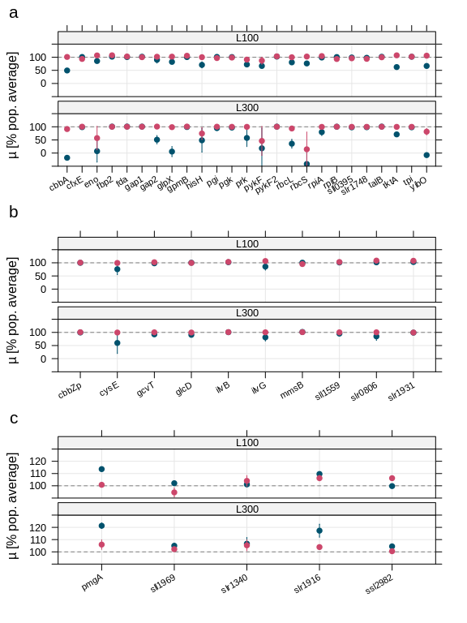

```r
print(plot_mutant_mu_2[[3]], position = c(0,0,1,0.36))
grid.text(label = c("a", "b", "c"), x = c(0.03, 0.03, 0.03),
  y = c(0.98, 0.66, 0.33), gp = gpar(cex = 1.3))
```

**Supplemental Figure.** Estimated growth rate of selected mutants. Mutant growth rate was determined from depletion of sgRNAs over time as described in Methods (mean and standard deviation of two sgRNAs per gene). Growth rate is displayed as % of population growth rate. Red - uninduced control, blue - induced culture. **a** Selected genes from the Calvin cycle. **b** Selected genes for photorespiration. **c** Selected faster growing mutants.

#### Saving processed data frames as Supplemental Data

1. Complete original data frame (including ncRNAs) with extra columns for mutant growth rate relative growth rate change in %. This is **Supplemental Data S4**.

```r
# merge master data frame with predicted growth rates
df_all <- df_mu %>% ungroup %>%

  # summarize mutant growth rate as mean and stdev
  group_by(sgRNA_short, condition, induction) %>%
  summarize(
    locus = locus[1],
    population_growth_rate = average_growth_rate[1],
    mean_mutant_growth_rate = mean(mutant_growth_rate),
    stdev_mutant_growth_rate = sd(mutant_growth_rate)
  ) %>%

  # add relative change
  mutate(mutant_growth_rate_percent =
    mean_mutant_growth_rate/population_growth_rate*100) %>%

  # select only growth rate-related columns and merge
  select(sgRNA_short, condition, induction,
    mean_mutant_growth_rate, mutant_growth_rate_percent) %>%
  left_join(df_all, .) %>%

  # remove unnecessary columns
  select(
    -FC, -Gene.ontology.IDs, -Process.abbr, -Pathway.abbr,
    -baseMean, -lfcSE, -stat, -pvalue, -Gene.names, -Length,
    -MolWeight, -location, -start_bp, -end_bp, -Process, -Pathway
  )
```

```
Column `condition` joining factor and character vector, coercing into character vector
```

```r
# and save to disk
write_csv(df_all, "../processed_data/Supplemental_data_S4.csv")
```

2. Selected genes for photorespiation, Calvin cycle, and increased growth rate. This is **Supplemental Data S6**.

```r
df_all %>% ungroup %>%

  # select subset of sgRNAs and conditions
  filter(
    locus %in% c(list_calvin, list_photores, list_faster),
    condition %in% c("L100", "L300"),
    timepoint == 0,
    sgRNA_index == 1
  ) %>%

  # select only important columns
  select(sgRNA_short, condition, induction, locus,
    average_growth_rate, mean_mutant_growth_rate,
    mutant_growth_rate_percent) %T>% print %>%

  write_csv("../processed_data/Supplemental_data_S6.csv")
```

| sgRNA_short | condition | induction | locus | average_growth_rate | mean_mutant_growth_rate | mutant_growth_rate_percent |
| --- | --- | --- | --- | --- | --- | --- |
| cbbA | L100 | i | sll0018 | 0.0315 | 0.015595806 | 49.510497 |
| cbbA | L100 | u | sll0018 | 0.0289 | 0.029210613 | 101.074786 |
| cbbA | L300 | i | sll0018 | 0.0710 | -0.012746119 | -17.952280 |
| cbbA | L300 | u | sll0018 | 0.0761 | 0.069511194 | 91.341910 |
| cbbZp | L100 | i | sll1349 | 0.0315 | 0.031509827 | 100.031196 |
| cbbZp | L100 | u | sll1349 | 0.0289 | 0.029109643 | 100.725408 |
| cbbZp | L300 | i | sll1349 | 0.0710 | 0.070698039 | 99.574703 |
| cbbZp | L300 | u | sll1349 | 0.0761 | 0.076600780 | 100.658056 |
| cfxE | L100 | i | sll0807 | 0.0315 | 0.031807027 | 100.974688 |
| cfxE | L100 | u | sll0807 | 0.0289 | 0.027012296 | 93.468151 |

[output cut: 150 more lines]

## Transcriptome of selected mutants analysed by RNA-Seq

Some genes in the sgRNA library were found to confer a growth advantage in competition experiments when repressed. These faster growing mutants were *pmgA*, *sll1969*, *slr1340*, *slr1916*, and *ssl2982*. These genes were grown in high light conditions (300 µmol photons m<sup>-2</sup> s<sup>-1</sup>) in turbidostat regime identical to the conditions that the complete mutant library was grown before. The mRNA of these samples was extracted, purified and quantitatively analyzed using RNA-Seq. The reads per gene were processed using `DESeq2` in the same way as all other CRISPRi library samples before. The purpose of this analysis is to find differences between faster-growing sgRNA mutants compared to the NT0 (no-target sgRNA) control. The hypothesis is that these mutants have an effect on global regulation of the cell.

```r
df_rnaseq <- read_csv("../raw_data/transcriptomics_selected_mutants.csv") %>%

  # filter out pmgA condition and un-annotated ORFs
  filter(
    !grepl("MYO\\_|SGL\\_", Name),
    Condition != "pmgA")

head(df_rnaseq)
```

| Name | Pathway | Protein | baseMean | log2FoldChange | lfcSE | stat | pvalue | padj | Condition | Significance | RPKM | Process | Direction |
| --- | --- | --- | --- | --- | --- | --- | --- | --- | --- | --- | --- | --- | --- |
| ndhK2 | NA | NA | 92.74514 | 0.08330249 | 0.20977853 | 0.3970973 | 0.69129571 | 0.8945788 | sll1969 | No | 11.82013 | No annotation | None |
| sll0002 | Drug and analog sensitivity | penicillin-binding protein | 2745.18660 | 0.12840000 | 0.09238213 | 1.3898791 | 0.16456559 | 0.5844507 | sll1969 | No | 71.20394 | Other categories | None |
| sll0005 | NA | hypothetical protein | 1802.07880 | -0.40760748 | 0.21009311 | -1.9401278 | 0.05236416 | 0.4616538 | sll1969 | No | 49.03665 | Hypothetical | None |
| sll0006 | Aspartate family | putative aminotransferase | 2194.13974 | -0.33330406 | 0.18472884 | -1.8042882 | 0.07118614 | 0.4884649 | sll1969 | No | 106.22849 | Amino acid biosynthesis | None |
| sll0007 | NA | hypothetical protein | 717.58351 | -0.15913179 | 0.14070100 | -1.1309927 | 0.25805818 | 0.6577840 | sll1969 | No | 79.81261 | Hypothetical | None |
| sll0008 | NA | unknown protein | 122.90784 | -0.09655182 | 0.17950182 | -0.5378877 | 0.59065456 | 0.8472505 | sll1969 | No | 15.76441 | Unknown | None |

#### Overview of mutants gene expression

We can start to explore differential regulation using a volcano plot.

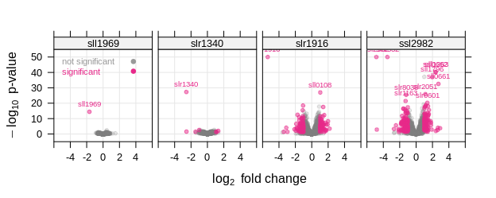

```r
plot_volcanoplot <- df_rnaseq %>%

  xyplot(-log10(padj) ~ setNames(log2FoldChange, Name) |
      factor(Condition), .,
    as.table = TRUE, groups = Significance,
    xlab = bquote(log[2] ~ "fold change"), ylab = bquote(-log[10] ~ "p-value"),
    par.settings = custom.lattice, layout = c(4, 1),
    cex = 0.6, pch = 19, col = c(grey(0.5, 0.4), "#E7298A"),
    scales = list(alternating = FALSE),
    between = list(x = 0.4, y = 0.4),
    ylim = c(-5, 55), xlim = c(-6, 6),
    panel = function(x, y, ...) {
      panel.grid(h = -1, v = -1, col = grey(0.9))
      # trim extremely far outside p-values to -log10(p) = 50 so that they are still
      # in visible range
      y <- replace(y, y >= 50, 50)
      panel.xyplot(x, y, alpha = 0.5, ...)
      # select top diff expr genes and plot labels
      sel <- which(!between(x, -1, 1) & y >= 20 |
        (names(x) %in% c("sll1969", "slr1340", "slr1916", "ssl2982")[panel.number()]))
      panel.text(x[sel], y[sel]+5, labels = names(x[sel]), cex = 0.6, col = "#E7298A")
      panel.key(c("not significant", "significant"), col = c(grey(0.6), "#E7298A"),
        pch = 19, corner = c(0.1, 0.9), cex = 0.7)
    }
  )

print(plot_volcanoplot)
```

Apparently, only few genes were differentially expressed in *sll1969* and *slr1340*, while considerably more were different in mutants *slr1916*, *ssl2982* and *pmgA* (not shown). In the next step, we have a look at the overlap between significantly regulated genes between mutants. One way is to use a heat map for visual inspection and cluster the data according to expression similarity as was done for the complete sgRNA library before.

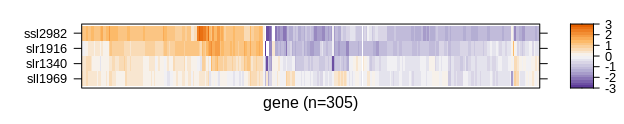

```r
# filter for significant genes only (same critera Johannes used)
sig_genes <- df_rnaseq %>% filter(
    !between(log2FoldChange, -1, 1), padj <= 0.05) %>%
  pull(Name) %>% unique

# prepare matrix for plotting heat map and plot
sig_genes_mat <- df_rnaseq %>% filter(Name %in% sig_genes) %>%

  # spread to matrix
  select(Name, Condition, log2FoldChange) %>%
  spread(Condition, log2FoldChange) %>%
  select(Name, sll1969, slr1340, slr1916, ssl2982) %>%

  # reorder matrix by simple pre-clustering with hclust
  column_to_rownames("Name") %>% as.matrix %>% replace_na(0) %>%
  {.[dist(.) %>% hclust(., method = "ward.D2") %>% {.$order}, ]}


# plot genes
plot_heatmap <- levelplot(sig_genes_mat,
  col.regions = colorRampPalette(rev(RColorBrewer::brewer.pal(5, "PuOr"))),
  as.table = TRUE, aspect = "fill", at = seq(-3, 3, 0.25),
  xlab = paste0("gene (n=", length(sig_genes), ")"),
  ylab = "",
  scales = list(alternating = FALSE, x = list(draw = FALSE))
)

print(plot_heatmap)
```

The heat map shows that the mode of action seems overall similar for the first four genes. But *pmgA* had a different if not even inverted expression pattern and was exlcuded from further analysis, also because RNAseq was conducted at a different occasion than for the other genes.

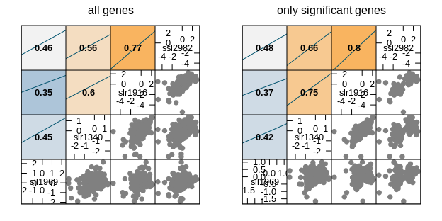

```r
plot_splom <- lapply(c(FALSE, TRUE), function(s) {

  # filter genes conditionally
  if (s) {df_rnaseq <- filter(df_rnaseq, Name %in% sig_genes)}

  df_rnaseq %>%

  # spread log2FC condition-wise
  select(Name, Process, Condition, log2FoldChange) %>%
  spread(Condition, log2FoldChange) %>%
  select(sll1969:ssl2982) %>%

  custom_splom( ~ .,
    main = ifelse(s, "only significant genes", "all genes")
  )

})

print(plot_splom[[1]], split = c(1,1,2,1), more = TRUE)
print(plot_splom[[2]], split = c(2,1,2,1))
```

Additionally, we can also quantify the overlap of DEG between the four mutants, in a type of Venn diagram analysis.

```r
df_rnaseq %>%

  # filter only sign. genes
  filter(Name %in% sig_genes) %>%
  select(Name, Condition, Significance) %>%

  # group by gene and count significant hits per condition (max 4)
  group_by(Name) %>%
  summarize(
    hits = Condition[which(Significance == "Yes")] %>% stringr::str_flatten(collapse = ", ")
  ) %>% pull %>% table %>% sort(decreasing = TRUE) %>% enframe
```

| name | value |
| --- | --- |
| ssl2982 | 163 |
| slr1916, ssl2982 | 79 |
| slr1916 | 55 |
| slr1340, slr1916 | 3 |
| slr1340, slr1916, ssl2982 | 3 |
| sll1969 | 1 |
| slr1340 | 1 |

#### Clustering and KEGG pathway enrichment

The next step is to look for meaningful genes or patterns that could explain the observed increased growth rate. We can look for interesting clusters from the subset of significantly regulated genes. We can see what automated (and objective) methods will suggest as optimal number of clusters when using `kmeans` instead of `hclust` (this method does not support `hclust`).

```
Clustering k = 1,2,..., K.max (= 10): .. done
Bootstrapping, b = 1,2,..., B (= 100)  [one "." per sample]:
.................................................. 50
.................................................. 100
```

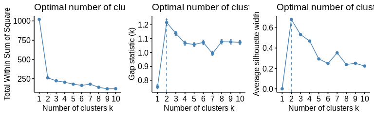

```r
gridExtra::grid.arrange(ncol = 3,
  fviz_nbclust(sig_genes_mat, kmeans, method = "wss"),
  fviz_nbclust(sig_genes_mat, kmeans, method = "gap_stat"),
  fviz_nbclust(sig_genes_mat, kmeans, method = "silhouette")
)
```

Two clusters seems to be the consensus optimal number of clusters. This indicates that the mode of action is very similar for those, only the degree of regulation (i.e. FC) is different. This could be a consequence of slightly different cultivation conditions, such as growth rate or generation time for the individual sgRNA mutant turbidostats.

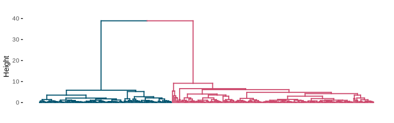

```r
# computing clusters with same method as in heatmap
# we omit re-scaling the data as we assume it is already scaled by DESeq2
clusters <- sig_genes_mat %>% dist %>%
  hclust(method = "ward.D2") %>% cutree(k = 2)

plot_clusters <- fviz_dend(sig_genes_mat %>% dist %>%
  hclust(method = "ward.D2"), k = 2, main = "",
  k_colors = custom.lattice()$superpose.symbol$col[1:2],
  show_labels = FALSE
)

print(plot_clusters)
```

Next we can look if there are any genes enriched for specific pathways for the complete group of differentially expressed genes, or within each individual cluster. For the first task, there was a slight but not very significant enrichment of amino acid synthesis pathways. The enrichment is not very significant because the number of differentially expressed genes is low. For the second task, also only few pathways are enriched per cluster.

```r
# Gene enrichment methods for the selected gene subset
# 1. KEGG module enrichment for list of sig reg genes
sig_genes %>% enrichMKEGG(organism = 'syn', minGSSize = 1,
  pvalueCutoff = 1, qvalueCutoff = 1) %>%
  {.@result %>% filter(Count >= 2)}
```

| ID | Description | GeneRatio | BgRatio | pvalue | p.adjust | qvalue | geneID | Count |
| --- | --- | --- | --- | --- | --- | --- | --- | --- |
| M00097 | beta-Carotene biosynthesis, GGAP => beta-carotene | 2/24 | 4/398 | 0.01943950 | 0.2336683 | 0.2221634 | slr0940/slr1254 | 2 |
| M00053 | Pyrimidine deoxyribonuleotide biosynthesis, CDP/CTP => dCDP/dCTP,dTDP/dTTP | 2/24 | 5/398 | 0.03120635 | 0.2336683 | 0.2221634 | sll1852/sll1258 | 2 |
| M00155 | Cytochrome c oxidase, prokaryotes | 2/24 | 6/398 | 0.04509154 | 0.2336683 | 0.2221634 | slr1136/slr1137 | 2 |
| M00161 | Photosystem II | 2/24 | 9/398 | 0.09680780 | 0.2792611 | 0.2655114 | sll1867/slr0927 | 2 |
| M00145 | NAD(P)H:quinone oxidoreductase, chloroplasts and cyanobacteria | 2/24 | 20/398 | 0.34316223 | 0.3932449 | 0.3738831 | sll1732/slr1291 | 2 |

```r
# This result is not meaningful, there are no more than 2
# genes per module enriched.
# 2. KEGG pathway enrichment using kegga

sig_genes %>% kegga(species.KEGG = "syn", FDR = 0.05, trend = FALSE) %>%
  arrange(P.DE) %>% filter(P.DE <= 0.1)
```

| Pathway | N | DE | P.DE |
| --- | --- | --- | --- |
| Taurine and hypotaurine metabolism | 5 | 2 | 0.02140183 |
| Tryptophan metabolism | 6 | 2 | 0.03110497 |
| Two-component system | 66 | 7 | 0.03683214 |
| Carotenoid biosynthesis | 9 | 2 | 0.06795095 |
| Photosynthesis | 63 | 6 | 0.08109039 |
| Benzoate degradation | 2 | 1 | 0.09564565 |
| Sphingolipid metabolism | 2 | 1 | 0.09564565 |

```r
# 3. Trying pathway enrichment for specific clusters 1 and 2.
kegga_result <- clusters %>%
  enframe(name = "protein", value = "cluster") %>%

  plyr::dlply(.variables = 'cluster', function(x)  x$protein) %>%
    kegga(species.KEGG = "syn", FDR = 0.05, trend = FALSE) %>%
  filter_at(vars(starts_with("P.")), any_vars(. <= 0.05))

print(kegga_result)
```

| Pathway | N | X1 | X2 | P.1 | P.2 |
| --- | --- | --- | --- | --- | --- |
| Photosynthesis | 63 | 6 | 0 | 0.01042279 | 1.00000000 |
| Alanine, aspartate and glutamate metabolism | 25 | 3 | 0 | 0.03908918 | 1.00000000 |
| Sphingolipid metabolism | 2 | 0 | 1 | 1.00000000 | 0.03569369 |
| Porphyrin and chlorophyll metabolism | 53 | 0 | 4 | 1.00000000 | 0.01237587 |
| Carotenoid biosynthesis | 9 | 2 | 0 | 0.02924594 | 1.00000000 |

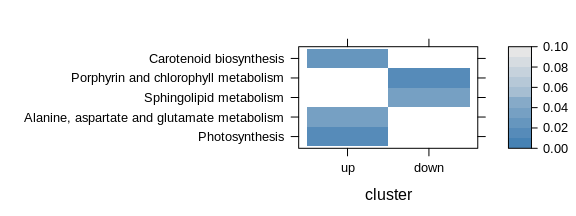

```r
# plot the resut
kegga_result %>% select(Pathway, P.1:P.2) %>% rename(up = P.1, down = P.2) %>%

  # turn into matrix
  column_to_rownames("Pathway") %>% as.matrix %>% {t(.)} %>%

  # plot result as heatmap again
  levelplot(
    col.regions = colorRampPalette(c("steelblue", grey(0.9)))(11),
    as.table = TRUE, aspect = "fill", at = seq(0, 0.1, 0.01),
    xlab = "cluster", ylab = ""
  )
```

#### Network analysis

The next step is looking at interesting candidates that can potentially have an effect on growth rate. Known examples for genes with positive correlation with growth rate would be ribosomal genes, central carbon metabolism enzymes or ATP synthase.

```r
# We create a new data frame with a selection of all interesting genes from cluster
# 1 and 2 to be used for String DB, or simple heatmap plotting
df_sig_genes <- clusters %>%
  enframe(name = "locus", value = "cluster") %>%

  # join cluster data with RNAseq data
  left_join(df_rnaseq %>%
    select(Name, Condition, log2FoldChange, padj, Pathway, Protein) %>%
    rename(locus = Name)) %>%

  # join with additional annotation
  left_join(df %>% ungroup %>%
    select(locus, Process, Process.abbr, Gene.names) %>%
    filter(!duplicated(locus))) %>%

  arrange(cluster, Condition, log2FoldChange)
```

Save list of genes with significant change in at least one of four conditions (CRISPRi repression mutants) as **Supplemental Data S7**.

```r
write_csv(df_sig_genes, "../processed_data/Supplemental_data_S7.csv")
```

#### Differential expression of selected genes

First we can make a table of the genes that are down-regulated in several conditions, in the same direction. This requires to omit the p-value criterium for now, as many genes might have the same direction of regulation (as shown in heat map) but are not significant as the fold change is too little.

```r
df_sig_genes_filtered <- df_sig_genes %>%

  # summarize number of conditions (mutants) where gene appears to be regulated
  group_by(locus) %>%
  summarize(
    up_reg = sum(log2FoldChange >= log2(1.5)),
    down_reg = sum(log2FoldChange <= log2(1/1.5)),
    mean_log2_FC = mean(log2FoldChange),
    Gene.names = Gene.names[1] %>% gsub("s[sl][rl][0-9]{4}", "", .),
    Protein = Protein[1] %>% substr(1, 50)
  ) %>%

  # sort by number of down-regulated samples
  filter(up_reg >= 3 | down_reg >= 3) %>%
  arrange(desc(up_reg), desc(down_reg), desc(mean_log2_FC))

df_sig_genes_filtered
```

| locus | up_reg | down_reg | mean_log2_FC | Gene.names | Protein |
| --- | --- | --- | --- | --- | --- |
| sll1691 | 4 | 0 | 1.2402704 |  | hypothetical protein |
| sll0493 | 4 | 0 | 0.8810448 |  | hypothetical protein |
| sll1011 | 4 | 0 | 0.7816535 |  | hypothetical protein |
| sll0661 | 3 | 0 | 1.3447509 |  | hypothetical protein YCF35 |
| ssr2153 | 3 | 0 | 1.2724922 |  | unknown protein |
| slr1919 | 3 | 0 | 1.2669183 |  | putative protein kinase |
| sll0662 | 3 | 0 | 1.1974981 |  | 4Fe-4S type iron-sulfur protein, probable glutared |
| slr2006 | 3 | 0 | 1.1281068 |  | hypothetical protein |
| slr1291 | 3 | 0 | 1.1127909 | ndhD2 | NADH dehydrogenase subunit 4 |
| slr0940 | 3 | 0 | 1.0852377 | crtQ | zeta-carotene desaturase |

[output cut: 66 more lines]

```r
#   write_csv(df_sig_genes_filtered, "~/Desktop/reg_genes_FC1_5.csv")
```

Next, we simply plot the most interesting genes as heatmap or correlation plot using the `corrplot` package.

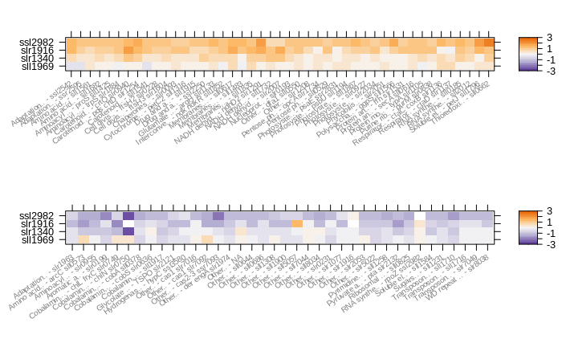

```r
# select only consensus regulated genes (exclude pmgA, cluster 1+3)
# and annotated genes
plot_sig_genes <- lapply(1:2, function(clust) {

  df_sig_genes %>% filter(cluster == clust, !is.na(Pathway)) %>%

  # merge pathway and gene name
  mutate(Gene.names = paste0(substr(Pathway, 1,10), ".. - ", Gene.names)) %>%
  select(Gene.names, Condition, log2FoldChange) %>%

  # spread
  spread(Condition, log2FoldChange) %>%
  select(Gene.names, sll1969, slr1340, slr1916, ssl2982) %>%

  # and convert to matrix
  column_to_rownames("Gene.names") %>% as.matrix %>%

  # plot
  levelplot(
    col.regions = colorRampPalette(rev(RColorBrewer::brewer.pal(5, "PuOr"))),
    as.table = TRUE, aspect = "fill", at = seq(-3, 3, 0.25),
    xlab = "", ylab = "",
    scales = list(x = list(rot = 35, cex = 0.6, col = grey(0.5)))
  )

})

print(plot_sig_genes[[1]], position = c(0,0.5,1,1), more = TRUE)
print(plot_sig_genes[[2]], position = c(0,0,1,0.5))
```

An alternative is to plot genes per group in form of a dotplot instead of heatmap. The focus here should be on functional groups instead of single genes. Even more concise is a simple barchart summary of up and down-regulated gene per group.

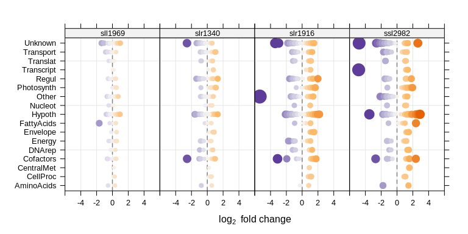

```r
# genes of particular interest
selected_genes <- df_sig_genes %>%
  filter(log2FoldChange >= 2 | log2FoldChange <= -2) %>%
  pull(locus) %>% unique
selected_genes <- c(selected_genes, "sll1316",
   "sll1796", "slr1291", "slr2007", "sll1732",
   "ssr2016", "slr0940", "slr1254", "sll1541",
   "slr0947", "slr0081", "slr2034", "sll0617",
   "slr0749", "slr0750", "slr0506", "sll1969")

plot_dots <- xyplot(factor(Process.abbr) ~ setNames(log2FoldChange, locus) |
      factor(Condition), df_sig_genes, as.table = TRUE,
    xlab = bquote(log[2] ~ "fold change"), ylab = "",
    par.settings = custom.lattice, layout = c(4, 1),
    scales = list(alternating = FALSE), xlim = c(-6, 6),
    panel = function(x, y, subscripts, ...) {
      panel.grid(h = -1, v = -1, col = grey(0.9))
      panel.abline(v = 0, lwd = 1.5, lty = 2, col = grey(0.5))
      cols = scales::rescale(x, from = c(-3, 3), to = c(1, 20)) %>%
        replace(., . < 1, 1) %>% replace(., .> 20, 20)
      cols = colorRampPalette(rev(RColorBrewer::brewer.pal(5, "PuOr")))(20)[round(cols)]
      panel.xyplot(x, y, pch = 19, cex = 0.6+(0.4*abs(x)), col = cols)
      sel <- which(names(x) %in% selected_genes & (x >= 1 | x <= -1))
      #panel.xyplot(x[sel], y[sel], cex = 1.2+(0.4*abs(x[sel])), col = grey(0.3))
      #panel.text(x[sel], y[sel], labels = names(sel), cex = 0.6, col = grey(0.3),
      #  pos = 3, offset = -2)
    }
  )

print(plot_dots)
```

This is going to be Figure 4, the summary of the transcriptomics part.

```r
print(plot_mutant_mu[[1]], position = c(0,0.77,1,1.03), more = TRUE)
print(plot_volcanoplot, position = c(0,0.56,1,0.84), more = TRUE)
```

```r
print(plot_heatmap, position = c(0.037,0.44,0.987,0.59), more = TRUE)
print(plot_dots, position = c(0,0,1,0.484))
```

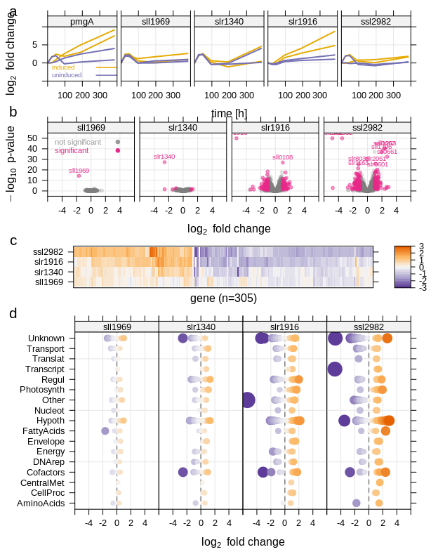

```r
grid.text(label = c("a", "b", "c", "d"), x = rep(0.03, 4),
  y = c(0.98, 0.8, 0.57, 0.44), gp = gpar(cex = 1.3))
```

## Droplet sorting of lactate over-producing strains

The sgRNA mutant library was grown in presence of inducer, encapsulated in microfluidic droplets and injected with a fluorecent reagent to monitor lactate production over time. Highly fluorescent droplets were then sorted and recovered, the sgRNA amplified by PCR and sequenced by NGS. The following plot shows lactate production over time by selected over-producing sgRNA mutants.

```r
# original data was re-organized to long format
df_lac_prod <- bind_rows(.id = "setup",
    read_csv("../raw_data/lactate_measurement_batch.csv"),
    read_csv("../raw_data/lactate_measurement_photofluxostat.csv")
  ) %>%

  # add µmol/L*OD720 and per gDCW (using an average value of 0.4 gDCW/OD720)
  mutate(
    lactate_µmol_L_OD = lactate_µmol_L / OD_720,
    lactate_µmol_L_gDCW = lactate_µmol_L_OD * 0.4
  ) %>%

  # filter strains and adjust metadata
  filter(strain != "trxA2") %>%
  mutate(
    setup = recode(setup, `1` = "shake flask", `2` = "photonfluxostat"),
    strain = gsub("_[0-9]*$", "", strain) %>% factor(., unique(.))
  )

# preview data
df_lac_prod
```

| setup | strain | replicate | time_h | lactate_µmol_L | OD_720 | lactate_µmol_L_OD | lactate_µmol_L_gDCW |
| --- | --- | --- | --- | --- | --- | --- | --- |
| shake flask | NT0 | 1 | 0 | 0.00000 | 0.1000000 | 0.0000 | 0.00000 |
| shake flask | NT0 | 2 | 0 | 0.00000 | 0.1000000 | 0.0000 | 0.00000 |
| shake flask | serA | 1 | 0 | 0.00000 | 0.1000000 | 0.0000 | 0.00000 |
| shake flask | serA | 2 | 0 | 0.00000 | 0.1000000 | 0.0000 | 0.00000 |
| shake flask | pcnB | 1 | 0 | 0.00000 | 0.1000000 | 0.0000 | 0.00000 |
| shake flask | pcnB | 2 | 0 | 0.00000 | 0.1000000 | 0.0000 | 0.00000 |
| shake flask | gltA | 1 | 0 | 0.00000 | 0.1000000 | 0.0000 | 0.00000 |
| shake flask | gltA | 2 | 0 | 0.00000 | 0.1000000 | 0.0000 | 0.00000 |
| shake flask | gdhA | 1 | 0 | 0.00000 | 0.1000000 | 0.0000 | 0.00000 |
| shake flask | gdhA | 2 | 0 | 0.00000 | 0.1000000 | 0.0000 | 0.00000 |

[output cut: 44 more lines]

```
p-value for comparison of  NT0
 with  NT0 ssr2016 sdhB  =  1 NA NA NA NA NA 0.2253146 0.604509
p-value for comparison of  NT0
 with  NT0 serA pcnB gltA gdhA gltB  =  1 0.3648358 0.01621536 0.02084433 0.7706913 0.4766513 NA NA
```

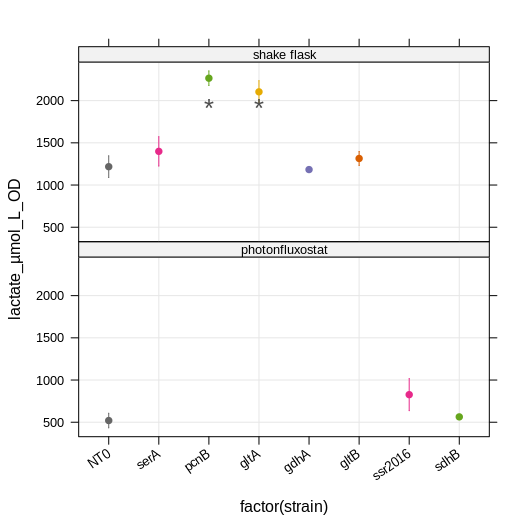

```r
# list of combinations
combinations <- list(
  unit = rep(c("lactate_µmol_L", "lactate_µmol_L_OD"), 2),
  setup = rep(c("shake flask", "photonfluxostat"), each = 2)
)

# change color scheme to black for NT0 control
custom_lattice <- custom.lattice()
custom_lattice$superpose.symbol$col <- RColorBrewer::brewer.pal(8, "Dark2")[c(8,4,5,6,3,2,4,5)]


# dot plot
plot_lac_prod <- lapply(1:4, function(i) {

  xyplot(get(combinations$unit[i]) ~ factor(time_h),
    filter(df_lac_prod, setup == combinations$setup[i]),
    groups = strain, as.table = TRUE,
    xlab = ifelse(i %in% c(3, 4), "time [h]", ""),
    ylab = ifelse(i %in% c(1, 3), "µmol L-1", "µmol L-1 OD720-1"),
    par.settings = custom_lattice,
    scales = list(alternating = FALSE),
    panel = function(x, y, groups, subscripts) {
      panel.grid(h = -1, v = -1, col = grey(0.9))
      panel.xyplot(x, y, groups = groups, subscripts = subscripts,
        type = "p", pch = 19, cex = 0.8)
      panel.errbars(x, y, groups = groups, subscripts = subscripts,
        ewidth = 0, type = "l", lwd = 2)
      if (i %in% c(1, 3)) {
        panel.key(points = FALSE, cex = 0.7, groups = groups, subscripts = subscripts)
      }
    }
  )
})

# alternatively a set of barplots for the same data
plot_lac_prod <- lapply(1:4, function(i) {

  xyplot(get(combinations$unit[i]) ~ factor(time_h),
    filter(df_lac_prod, setup == combinations$setup[i], time_h != 0),
    groups = strain, as.table = TRUE, lwd = 2,
    xlab = ifelse(i %in% c(3, 4), "time [h]", ""),
    ylab = ifelse(i %in% c(1, 3), "µmol L-1", "µmol L-1 OD720-1"),
    par.settings = custom_lattice,
    scales = list(alternating = FALSE),
    panel = function(x, y, ...) {
      panel.grid(h = -1, v = -1, col = grey(0.9))
      panel.barplot(x, y, beside = TRUE, ...)
      panel.xyplot(x, y, pch = 19, alpha = 0.4, ...)
      if (i %in% c(1, 3)) {
        panel.key(points = FALSE, cex = 0.7, ...)
      }
    }
  )
})

# conduct a t-test for the last time point
# only gltA and pcnB with the representation as µmol L-1 OD720-1
# is significant (p <= 0.05)
xyplot(lactate_µmol_L_OD ~ factor(strain) | setup,
  filter(df_lac_prod, time_h %in% c(30, 48)),
  groups = strain, layout = c(1,2),
  par.settings = custom_lattice, pch = 19,
  scales = list(alternating = FALSE, x = list(rot = 35)),
  panel = function(x, y, ...) {
    panel.grid(h = -1, v = -1, col = grey(0.9))
    panel.errbars(x, y, ewidth = 0, ...)
    panel.pvalue(x, y, std = "NT0", verbose = TRUE,
      col = grey(0.3), ...)
  }
)
```

```r
print(plot_lac_prod[[1]], position = c(0,0.49,0.53,1), more = TRUE)
print(plot_lac_prod[[2]], position = c(0.47,0.49,1,1), more = TRUE)
```

```r
print(plot_lac_prod[[3]], position = c(0.015,0,0.53,0.53), more = TRUE)
print(plot_lac_prod[[4]], position = c(0.47,0,1,0.53))
```

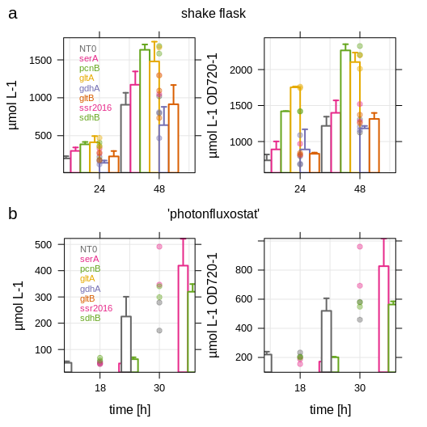

```r
grid.text(label = c("shake flask", "'photonfluxostat'"), x = c(0.5, 0.5),
  y = c(0.97, 0.5), gp = gpar(cex = 1))
grid.text(label = c("a", "b"), x = c(0.03, 0.03),
  y = c(0.97, 0.5), gp = gpar(cex = 1.3))
```

We can also have a look at relative increase in % productivity compared to NT0 control.

```r
df_lac_prod %>% filter(time_h != 0) %>%

  group_by(setup, time_h, strain) %>%
  summarize(mean_lac = mean(lactate_µmol_L_OD)) %>%
  mutate(mean_lac_percent = mean_lac/mean_lac[1])
```

[output not shown]

[output cut: 10 more lines]